# Oxfam America Website Content

##### Report last updated on July 10, 2019 at 03:45 PM

## Oxfam Website Content Summary

##### Period between 2019-01-01 and 2019-07-09.

• Data filtered for content > 50 page views during the specified time period.  
• Average engaged time: The amount of actively engaged time (in seconds) per page view.  
• Quality Depth: Ratio of page views that scrolled to at least 50% of the page.  
• Continued Journey: Ratio of page views that went to another page on our website.  
• Percent Organic Traffic: organic traffic is traffic that comes to our content through organic search, direct, or referall links from other sources. All other methods are considered to be promoted by Oxfam in some way. A lower percentage on this metric indicates a higher level of promotion.  
• Green bolded values indicate content that was in the top 75th percentile for the given metric relative to all other content in the dataset.  
• Red bolded values indicate content that was in the lower 25th percentile for the given metric relative to all other content in the dataset.

| Id | Content | Type | Views | Average Engaged Time | Quality Scroll Depth | Continued Journey | Percent Organic Traffic |
| --- | --- | --- | --- | --- | --- | --- | --- |
| 1 | 6-simple-reasons-we-should-raise-the-minimum-wage | politics of poverty blog | 16,282 | 82 | 67% | 4% | 98% |
| 2 | what-is-famine-and-how-can-we-stop-it | oa stories | 12,808 | 65 | 54% | 8% | 99% |
| 3 | whats-the-difference-between-sudan-and-south-sudan | oa stories | 12,482 | 70 | 49% | 2% | 100% |
| 4 | 10-everyday-food-brands-and-the-few-giant-companies-that-own-them | first person blog | 7,563 | 35 | 35% | 1% | 98% |
| 5 | whats-really-going-on-at-the-us-mexico-southern-border | oa stories | 6,747 | 71 | 63% | 5% | 97% |
| 6 | these-10-companies-make-a-lot-of-the-food-we-buy-heres-how-we-made-them-better | oa stories | 6,565 | 27 | 21% | 3% | 100% |
| 7 | does-the-american-dream-still-exist | politics of poverty blog | 6,423 | 59 | 55% | 2% | 100% |
| 8 | poor-versus-low-income-what-term-should-we-use | politics of poverty blog | 5,579 | 44 | 25% | 2% | 99% |
| 9 | top-10-things-you-need-to-know-about-oxfam | oa stories | 5,197 | 61 | 49% | 22% | 100% |
| 10 | 17-books-that-will-change-your-perspective-about-poverty-this-year | first person blog | 4,238 | 70 | 53% | 6% | 100% |

[output cut: 393 more lines]

# Dataset Summary Statistics

| Summary Stat | Average Engaged Time | Quality Scroll Depth | Continued Journey |
| --- | --- | --- | --- |
| Min. | 5 | 2% | 0% |
| 1st Qu. | 38 | 34% | 4% |
| Median | 53 | 46% | 9% |
| Mean | 54 | 46% | 12% |
| 3rd Qu. | 68 | 58% | 19% |
| Max. | 147 | 95% | 71% |

# Average Engaged Time Trends

• Data is smoothed to show general trends year-to-date.

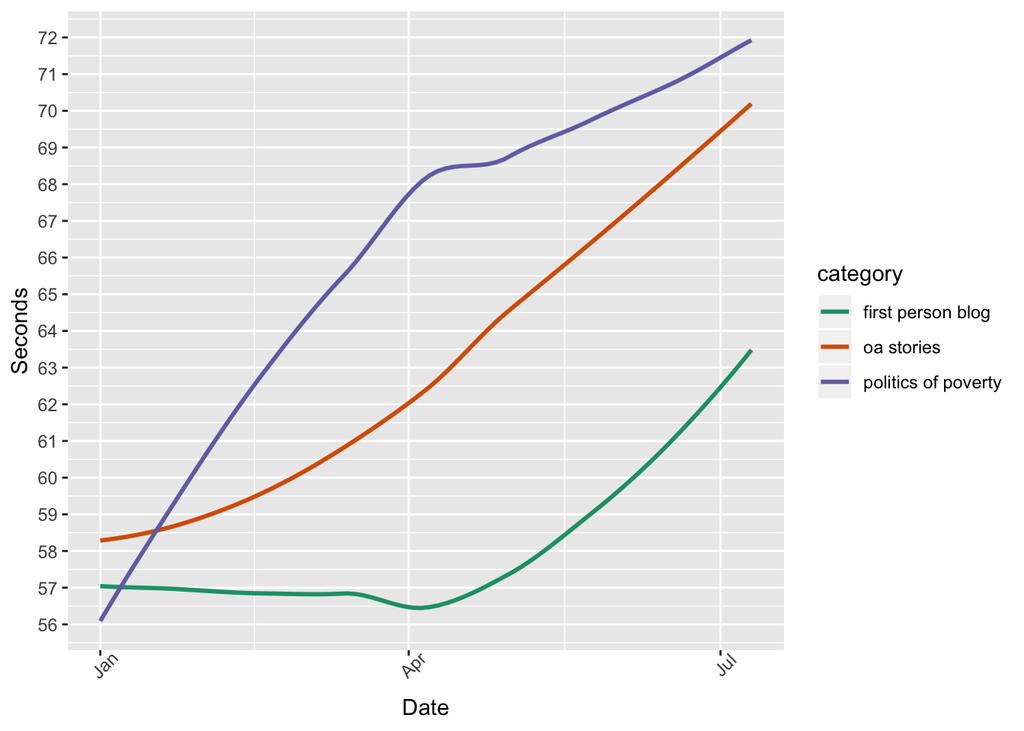

# Quality Depth Trends

• Data is smoothed to show general trends year-to-date.

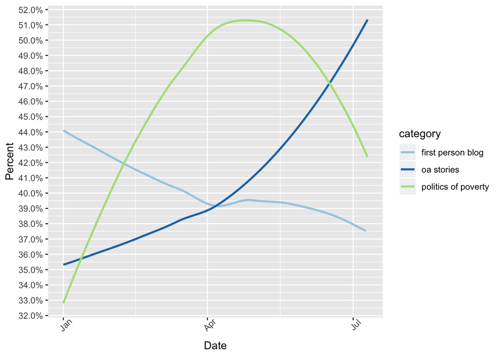

# Continued Journey Trends

• Data is smoothed to show general trends year-to-date.

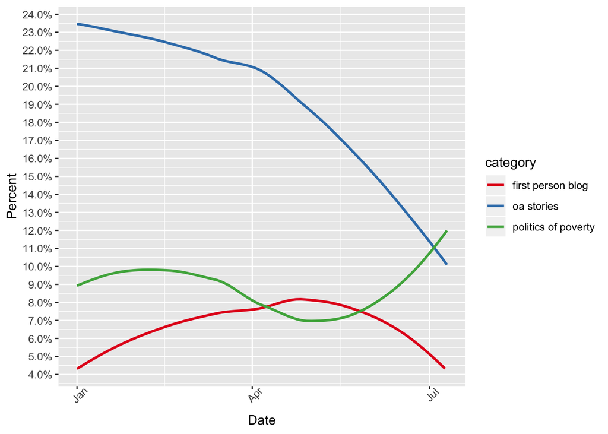